[figure not shown]

```python
from IPython.display import Image
Image("../src/photos/python_pandas.png")
```

# Pandas Series

a single vector representation of data

```python
num_arr = np.arange(5, 10)
```

```python
num_arr
```

```
array([5, 6, 7, 8, 9])
```

```python
# Passing a range into the Series()
pd.Series(num_arr)
```

```
0    5
1    6
2    7
3    8
4    9
dtype: int64
```

```python
# You Can label  the data inside a Series
label_arr = np.array(["a", "b", "c", "d", "e"])
```

```python
pd.Series(data = num_arr, index=label_arr)
```

```
a    5
b    6
c    7
d    8
e    9
dtype: int64
```

### Using a Dictionary to Create a series

```python
dict_1 = {'a' : 5, "b": 6, "c": 7, "d" : 8, "e":9}
```

```python
dict_1["a"]
```

```
5
```

```python
temp = pd.Series(dict_1)
```

```python
temp
```

```
a    5
b    6
c    7
d    8
e    9
dtype: int64
```

```python
temp["a"]
```

```
5
```

# Series Operation

Performing Operations on the elements inside the series

```python
dict_1 = {'a' : 5, "b": 6, "c": 7, "d" : 8, "e":9}
dict_2 = {'a' : 5, "b": 6, "c": 7, "e" : 8, "f":9}
```

```python
ser_1 = pd.Series(dict_1)
ser_2 = pd.Series(dict_2)
```

```python
ser_1
```

```
a    5
b    6
c    7
d    8
e    9
dtype: int64
```

```python
ser_2
```

```
a    5
b    6
c    7
e    8
f    9
dtype: int64
```

### Math and Checking for Values

```python
sum_series = ser_1 + ser_2
sum_series
```

```
a    10.0
b    12.0
c    14.0
d     NaN
e    17.0
f     NaN
dtype: float64
```

```python
sum_series.abs()
```

```
a    10.0
b    12.0
c    14.0
d     NaN
e    17.0
f     NaN
dtype: float64
```

```python
sum_series.sum()
```

```
53.0
```

```python
sum_series.mean()
```

```
13.25
```

```python
sum_series.median()
```

```
13.0
```

```python
sum_series.std()
```

```
2.9860788111948193
```

### Checking for NULL values

```python
sum_series.isnull()
```

```
a    False
b    False
c    False
d     True
e    False
f     True
dtype: bool
```

#### How many nulls?

```python
sum_series.isnull().sum()
```

```
2
```

```python
sum_series.notnull()
```

```
a     True
b     True
c     True
d    False
e     True
f    False
dtype: bool
```

### Checking for Data Types

```python
sum_series.dtype
```

```
dtype('float64')
```

## Accessing Series Elements

### Display the Values or the Index

```python
sum_series.values
```

```
array([10., 12., 14., nan, 17., nan])
```

#### Display the the Index

```python
sum_series.index
```

```
Index(['a', 'b', 'c', 'd', 'e', 'f'], dtype='object')
```

#### Display an Element

```python
sum_series[0]
```

```
10.0
```

### Slicing the Elements inside the Array

```python
sum_series[0:5]
```

```
a    10.0
b    12.0
c    14.0
d     NaN
e    17.0
dtype: float64
```

#### You can also pass in a list to access elements in a stepwise fashion

```python
sum_series[[0,2,5]]
```

```
a    10.0
c    14.0
f     NaN
dtype: float64
```

### Accessing Elements inside the Series By Index

```python
# Get an individual Element
sum_series["a"]
```

```
10.0
```

```python
# Access by the index values
sum_series["a":"c"]
```

```
a    10.0
b    12.0
c    14.0
dtype: float64
```

```python
# Take just a few elements
sum_series[["a", "e", "c"]]
```

```
a    10.0
e    17.0
c    14.0
dtype: float64
```

### Appending Elements into the Series

```python
sum_series.append(sum_series)
```

```
a    10.0
b    12.0
c    14.0
d     NaN
e    17.0
f     NaN
a    10.0
b    12.0
c    14.0
d     NaN
e    17.0
f     NaN
dtype: float64
```

### Accessing using specific functions

```python
sum_series.idxmax()
```

```
'e'
```

```python
sum_series.idxmin()
```

```
'a'
```

### Type Conversion

```python
sum_series.astype('str')
```

```
a    10.0
b    12.0
c    14.0
d     nan
e    17.0
f     nan
dtype: object
```

### Performing Fancy Indexing and Counting

```python
sum_series.value_counts()
```

```
17.0    1
14.0    1
12.0    1
10.0    1
dtype: int64
```

### Checking for Conditions on Specific Elements

```python
sum_series.where(sum_series > 12)
```

```
a     NaN
b     NaN
c    14.0
d     NaN
e    17.0
f     NaN
dtype: float64
```

```python
#check and change values
sum_series.where(sum_series > 12, 4242)
```

```
a    4242.0
b    4242.0
c      14.0
d    4242.0
e      17.0
f    4242.0
dtype: float64
```

### Masking Data According to Conditions

Convert Values to `NaN` or a value

```python
sum_series.mask(sum_series > 12)
```

```
a    10.0
b    12.0
c     NaN
d     NaN
e     NaN
f     NaN
dtype: float64
```

```python
sum_series.mask(sum_series > 12, 4343)
```

```
a      10.0
b      12.0
c    4343.0
d       NaN
e    4343.0
f       NaN
dtype: float64
```

### Applying Transformation to data

Defining functions can be passed into the `df.apply()` function to perform all the opertions on the elements inside the dataframe

```python
def even_odd(x):
    if x % 2 == 0:
        return True
    else:
        return False
```

```python
sum_series.apply(even_odd)
```

```
a     True
b     True
c     True
d    False
e    False
f    False
dtype: bool
```

```python
sum_series.tolist()
```

```
[10.0, 12.0, 14.0, nan, 17.0, nan]
```

```python
sum_series.sort_values()
```

```
a    10.0
b    12.0
c    14.0
e    17.0
d     NaN
f     NaN
dtype: float64
```

```python
sum_series.sort_values(ascending=False)
```

```
e    17.0
c    14.0
b    12.0
a    10.0
d     NaN
f     NaN
dtype: float64
```

```python
sum_series.set_axis(axis = 0, labels=[0, 1, 2, 3, 4, 5])
```

```python
sum_series
```

```
0    10.0
1    12.0
2    14.0
3     NaN
4    17.0
5     NaN
dtype: float64
```

### Pulling out Random Samples

```python
sum_series.sample(3)
```

```
4    17.0
0    10.0
2    14.0
dtype: float64
```

[figure not shown]

```python
Image("../src/photos/keep_calm_take_break.png")
```

# Pandas DataFrame

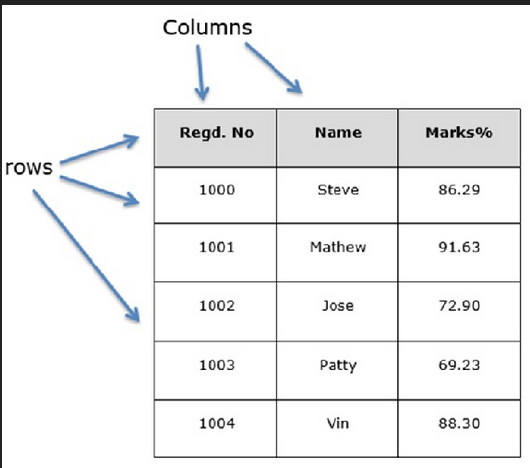

```python
Image("../src/photos/pandas_dataframes.png")
```

```python
two_dim_array = np.arange(30).reshape(5,6)
```

```python
two_dim_array
```

```
array([[ 0,  1,  2,  3,  4,  5],
       [ 6,  7,  8,  9, 10, 11],
       [12, 13, 14, 15, 16, 17],
       [18, 19, 20, 21, 22, 23],
       [24, 25, 26, 27, 28, 29]])
```

### Using the `DataFrame()`

`DataFrame(data=None, index=None, columns=None, dtype=None, copy=False)`

Two-dimensional size-mutable, potentially heterogeneous tabular data structure with labeled axes (rows and columns). Arithmetic operations align on both row and column labels. Can be thought of as a dict-like container for Series objects. The primary pandas data structure.

```python
df1 = pd.DataFrame(data = two_dim_array, index=[0,1,2,3,4],
                   columns=['A', "B", "C", "D", "E", "F"])
```

```python
type(df1)
```

```
pandas.core.frame.DataFrame
```

```python
df1
```

|  | A | B | C | D | E | F |
| --- | --- | --- | --- | --- | --- | --- |
| 0 | 0 | 1 | 2 | 3 | 4 | 5 |
| 1 | 6 | 7 | 8 | 9 | 10 | 11 |
| 2 | 12 | 13 | 14 | 15 | 16 | 17 |
| 3 | 18 | 19 | 20 | 21 | 22 | 23 |
| 4 | 24 | 25 | 26 | 27 | 28 | 29 |

### Pulling out information from the dataframe

```python
df1.index
```

```
Int64Index([0, 1, 2, 3, 4], dtype='int64')
```

```python
df1.columns
```

```
Index(['A', 'B', 'C', 'D', 'E', 'F'], dtype='object')
```

```python
df1.values
```

```
array([[ 0,  1,  2,  3,  4,  5],
       [ 6,  7,  8,  9, 10, 11],
       [12, 13, 14, 15, 16, 17],
       [18, 19, 20, 21, 22, 23],
       [24, 25, 26, 27, 28, 29]])
```

### Displaying More Information About your data

```python
# Peek at the first 2 rows
df1.head(2)
```

|  | A | B | C | D | E | F |
| --- | --- | --- | --- | --- | --- | --- |
| 0 | 0 | 1 | 2 | 3 | 4 | 5 |
| 1 | 6 | 7 | 8 | 9 | 10 | 11 |

```python
# Peek at the last 2 rows
df1.tail(2)
```

|  | A | B | C | D | E | F |
| --- | --- | --- | --- | --- | --- | --- |
| 3 | 18 | 19 | 20 | 21 | 22 | 23 |
| 4 | 24 | 25 | 26 | 27 | 28 | 29 |

[figure not shown]

```python
Image('../src/photos/haters_kitteh.png')
```

### Display The information about the elements in the frame

`df.info()` will let you see what values if any need to be transformed to fit inside your models

```python
df1.info()
```

```
<class 'pandas.core.frame.DataFrame'>
Int64Index: 5 entries, 0 to 4
Data columns (total 6 columns):
A    5 non-null int64
B    5 non-null int64
C    5 non-null int64
D    5 non-null int64
E    5 non-null int64
F    5 non-null int64
dtypes: int64(6)
memory usage: 280.0 bytes
```

### Display the Values in a Column

```python
df1["A"]
```

```
0     0
1     6
2    12
3    18
4    24
Name: A, dtype: int64
```

```python
df1.A
```

```
0     0
1     6
2    12
3    18
4    24
Name: A, dtype: int64
```

```python
df1[["A", "B","C"]]
```

|  | A | B | C |
| --- | --- | --- | --- |
| 0 | 0 | 1 | 2 |
| 1 | 6 | 7 | 8 |
| 2 | 12 | 13 | 14 |
| 3 | 18 | 19 | 20 |
| 4 | 24 | 25 | 26 |

```python
type(df1['A'])
```

```
pandas.core.series.Series
```

### Using the `describe()` function for Basic Stats Data

Generate descriptive statistics that summarize the central tendency, dispersion and shape of a dataset's distribution, excluding `NaN` values.

```python
df1.describe()
```

|  | A | B | C | D | E | F |
| --- | --- | --- | --- | --- | --- | --- |
| count | 5.000000 | 5.000000 | 5.000000 | 5.000000 | 5.000000 | 5.000000 |
| mean | 12.000000 | 13.000000 | 14.000000 | 15.000000 | 16.000000 | 17.000000 |
| std | 9.486833 | 9.486833 | 9.486833 | 9.486833 | 9.486833 | 9.486833 |
| min | 0.000000 | 1.000000 | 2.000000 | 3.000000 | 4.000000 | 5.000000 |
| 25% | 6.000000 | 7.000000 | 8.000000 | 9.000000 | 10.000000 | 11.000000 |
| 50% | 12.000000 | 13.000000 | 14.000000 | 15.000000 | 16.000000 | 17.000000 |
| 75% | 18.000000 | 19.000000 | 20.000000 | 21.000000 | 22.000000 | 23.000000 |
| max | 24.000000 | 25.000000 | 26.000000 | 27.000000 | 28.000000 | 29.000000 |

### Display the same information about a Column

```python
df1.A.describe()
```

```
count     5.000000
mean     12.000000
std       9.486833
min       0.000000
25%       6.000000
50%      12.000000
75%      18.000000
max      24.000000
Name: A, dtype: float64
```

### Adding and Dropping Column

```python
df1["G"] = df1.A + df1.B
```

```python
df1
```

|  | A | B | C | D | E | F | G |
| --- | --- | --- | --- | --- | --- | --- | --- |
| 0 | 0 | 1 | 2 | 3 | 4 | 5 | 1 |
| 1 | 6 | 7 | 8 | 9 | 10 | 11 | 13 |
| 2 | 12 | 13 | 14 | 15 | 16 | 17 | 25 |
| 3 | 18 | 19 | 20 | 21 | 22 | 23 | 37 |
| 4 | 24 | 25 | 26 | 27 | 28 | 29 | 49 |

```python
df1["G"]
```

```
0     1
1    13
2    25
3    37
4    49
Name: G, dtype: int64
```

```python
df1.drop("G", axis = 1, inplace=True)
```

```python
df1
```

|  | A | B | C | D | E | F |
| --- | --- | --- | --- | --- | --- | --- |
| 0 | 0 | 1 | 2 | 3 | 4 | 5 |
| 1 | 6 | 7 | 8 | 9 | 10 | 11 |
| 2 | 12 | 13 | 14 | 15 | 16 | 17 |
| 3 | 18 | 19 | 20 | 21 | 22 | 23 |
| 4 | 24 | 25 | 26 | 27 | 28 | 29 |